# Data Analysis for Business - Midterm Project

Edoardo Cocciò, Alexandra Tabarani, Marta Torella, Simone Filosofi

# Standard Deviated Group

Group members:

- Edoardo Cocciò - 282401
- Alexandra Tabarani - 282091
- Marta Torella - 284091
- Simone Filosofi - 284531

## Task 1

The dataset we are going to analyze is the “Telecom Churn” dataset, which contains information about US Telecom. For this first task, our objective is to predict customer churn, enabling the company to implement preventative measures to retain clients; as a matter of fact, by identifying customers at high risk of churn, the company can proactively offer targeted promotions to improve retention rates.

### EDA

We start by performing an exploratory data analysis (EDA) to understand the structure of the dataset and the relationships between the variables. Starting with a general overview of the dataset, we can see that it contains 3333 observations and 20 variables. The variables are a mix of numerical and categorical variable; we proceed by factoring the categorical variables in order to better deal with them later.

```
##  [1] "State"                  "Account.length"         "Area.code"
##  [4] "International.plan"     "Voice.mail.plan"        "Number.vmail.messages"
##  [7] "Total.day.minutes"      "Total.day.calls"        "Total.day.charge"
## [10] "Total.eve.minutes"      "Total.eve.calls"        "Total.eve.charge"
## [13] "Total.night.minutes"    "Total.night.calls"      "Total.night.charge"
## [16] "Total.intl.minutes"     "Total.intl.calls"       "Total.intl.charge"
## [19] "Customer.service.calls" "Churn"
```

#### Missing Values and Duplicates

A crucial step in the data analysis process is to check for missing values and duplicates in the dataset to ensure that the data is clean and ready for analysis; in our case we have no missing values and no duplicates. After ensuring dataset integrity, we proceed with the analysis.

#### Univariate Analysis

We proceed by conducting an univariate analysis of the variables in our dataset: our first step is to check the distribution of the target variable ‘Churn’; indeed, we identified the variable ‘Churn’ as the target of our analysis since, as previously stated, the goal of our first task is to build a model to predict customer churn. As shown by the below pie chart,the distribution of the target variable is unbalanced, with 85.5% of the customers not churning and 14.5% churning.

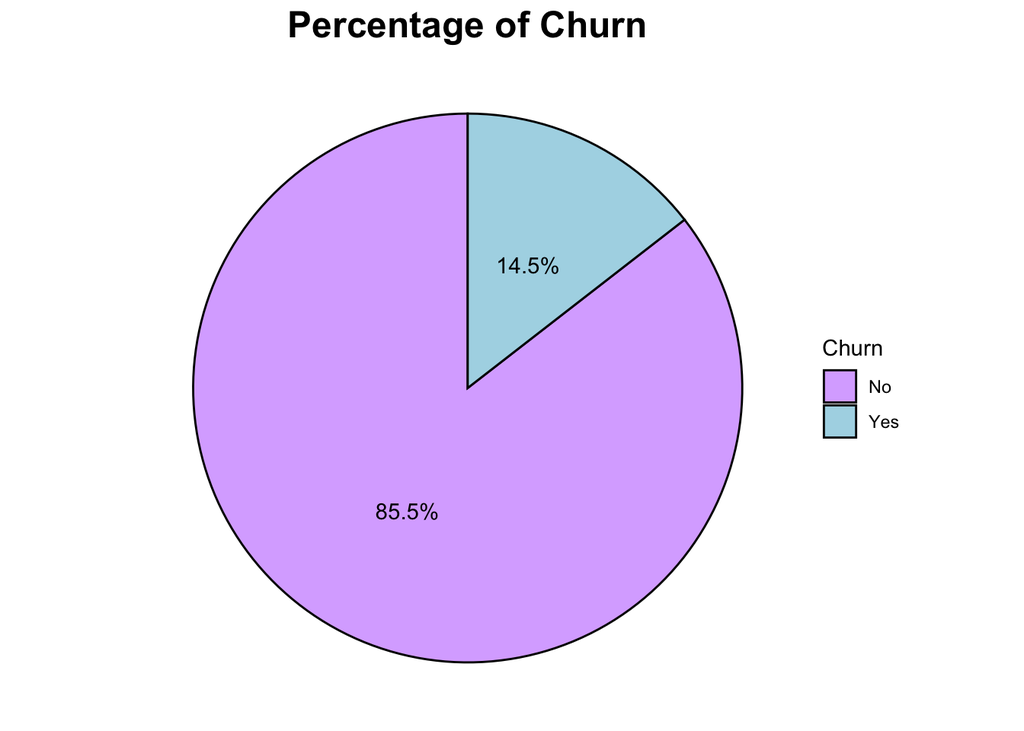

We now proceed with the univariate analysis of the numerical variables in the dataset. We will plot the distribution of the numerical variables by the target variable ‘Churn’ to see if there are any differences in the distribution of the numerical variables between the two levels of the target variable.

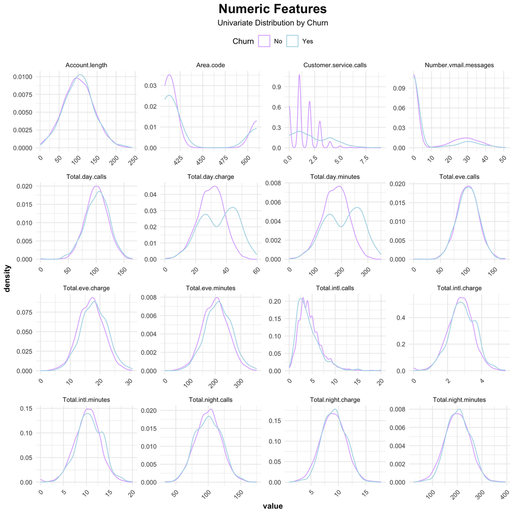

The above univariate analysis of the numerical variables shows that the variables distribution differs remarkably for the two levels of the target variable “Churn” in a couple of cases. Indeed, there’s a noticeable difference in the distribution of **customer service calls**: customers who churned seem to make more customer service calls, which could indicate a relationship between customer satisfaction and churn. It also appears that customers who churned tend to have slightly higher **total day minutes** and **total day charges**; this might suggest that customers with higher usage during the day are more likely to churn. The other variables do not show a significant difference in distribution between the two levels of the target variable.

Another remarkable imbalance can be found in the distribution of both **International.plan** and **Voice.mail.plan**. The majority of customers do not have an international plan nor a voice mail plan; this might suggest that these services are not very popular among customers.

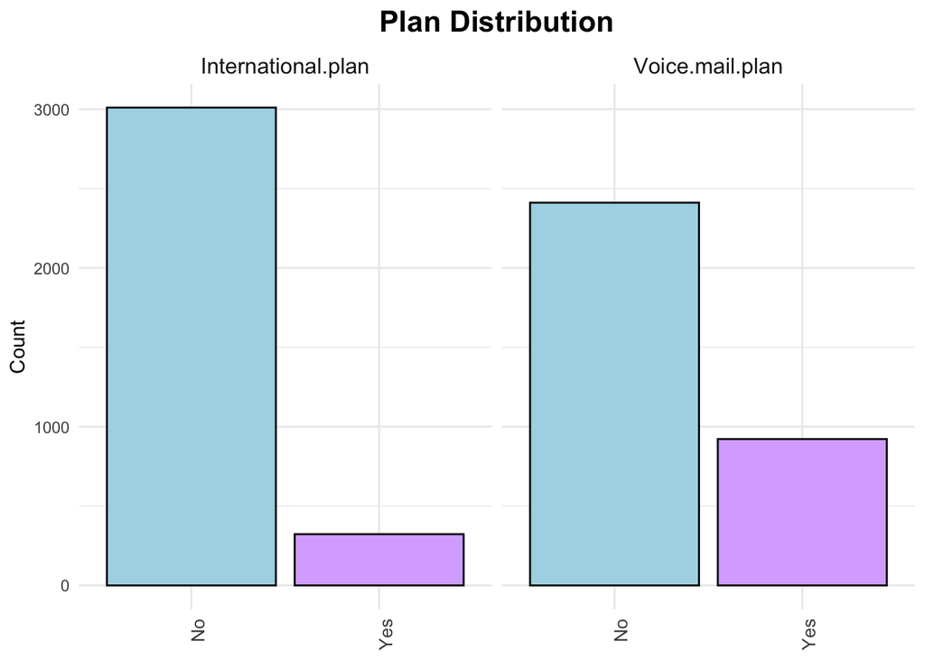

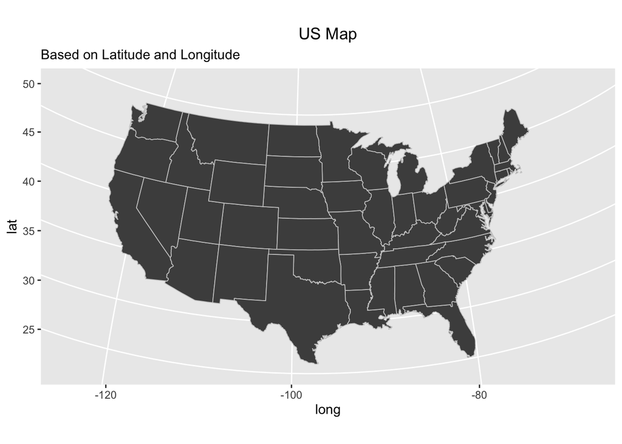

```r
us_map <- map_data("state") %>%
  as_tibble()

us_map %>%
  ggplot(aes(long, lat, map_id = region)) +
  geom_map(
    map =us_map,
    color = "gray80",
    fill = "gray30",
    size = 0.3
  ) +
  coord_map("ortho", orientation = c(39, -98, 0)) +
  labs(
    title = "US Map",
    subtitle = "Based on Latitude and Longitude"
  ) + theme(plot.title = element_text(hjust=0.5))
```

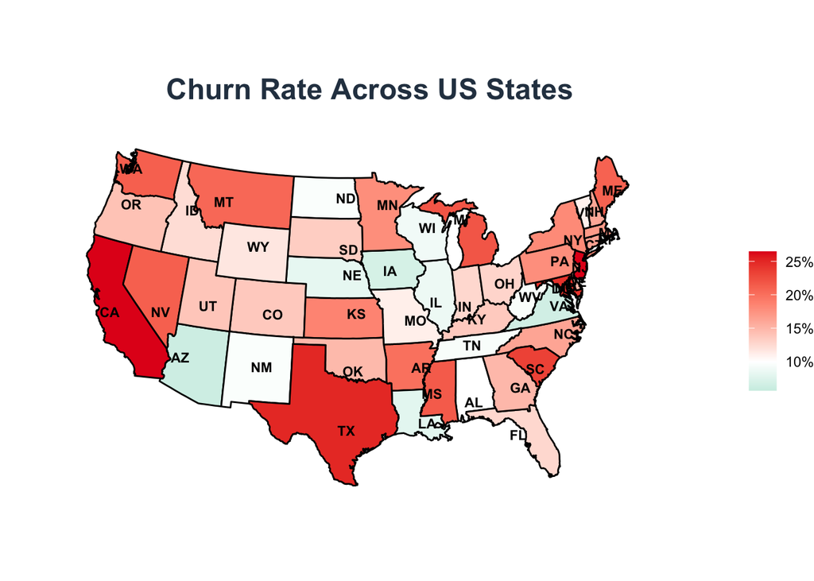

```r
state_names <- c(KS = "kansas", OH = "ohio", NJ = "new jersey", OK = "oklahoma",
                 AL = "alabama", MA = "massachusetts", MO = "missouri", LA = "louisiana",
                 WV = "west virginia", IN = "indiana", RI = "rhode island", IA = "iowa",
                 MT = "montana", NY = "new york", ID = "idaho", VT = "vermont",
                 VA = "virginia", TX = "texas", FL = "florida", CO = "colorado",
                 AZ = "arizona", SC = "south carolina", NE = "nebraska", WY = "wyoming",
                 HI = "hawaii", IL = "illinois", NH = "new hampshire", GA = "georgia",
                 AK = "alaska", MD = "maryland", AR = "arkansas", WI = "wisconsin",
                 OR = "oregon", MI = "michigan", DE = "delaware", UT = "utah",
                 CA = "california", MN = "minnesota", SD = "south dakota", NC = "north carolina",
                 WA = "washington", NM = "new mexico", NV = "nevada", DC = "district of columbia",
                 KY = "kentucky", ME = "maine", MS = "mississippi", TN = "tennessee",
                 PA = "pennsylvania", CT = "connecticut", ND = "north dakota")

churn.tbl <- data %>% select(State, Churn) %>%
  group_by(State) %>%
  summarize(
    total_customers = n(),
    churned_customers = sum(Churn == "True"),
    churn_rate = (churned_customers / total_customers),
    churn_rate_txt = scales::percent(churn_rate)
  ) %>%
  mutate(full_state = state_names[as.character(State)]) %>%
  ungroup() %>%
  left_join(us_map, by=c("full_state" = "region"))

us_map_sf <- st_as_sf(us_map, coords = c("long", "lat"), crs = 4326, agr = "constant")

centroids <- us_map_sf %>%
  group_by(region) %>%
  summarise(geometry = st_centroid(st_union(geometry)))

centroids_df <- as.data.frame(st_coordinates(centroids))
centroids_df$region <- centroids$region

churn.tbl <- churn.tbl %>%
  left_join(centroids_df, by = c("full_state" = "region"))

churn.tbl %>%
  ggplot(aes(long, lat)) +
  geom_map(
    aes(map_id = full_state),
    map = us_map,
    color = "gray86",
    fill = "gray30",
    size = 0.3
  ) + coord_map("ortho", orientation = c(39, -98, 0)) + geom_polygon(aes(group = group, fill = churn_rate), color="black") +
  scale_fill_gradient2("",low = "#18BC9C", mid = "white", high = "#E31A1C", midpoint = 0.10, labels = scales::percent) +
  geom_text(aes(x = X, y = Y, label = State), stat = "unique", size = 3, inherit.aes = FALSE, fontface = "bold") +
  theme_void() +
  theme(
    plot.title = element_text(size=18, face="bold", color = "#2C3E50"),
    legend.position = "right"
  ) +
  labs(
    title = "Churn Rate Across US States",
    x = "",
    y = ""
  ) +
  theme(
    plot.title = element_text(hjust = 0.5, face = "bold"),
  )
```

#### Correlation analysis

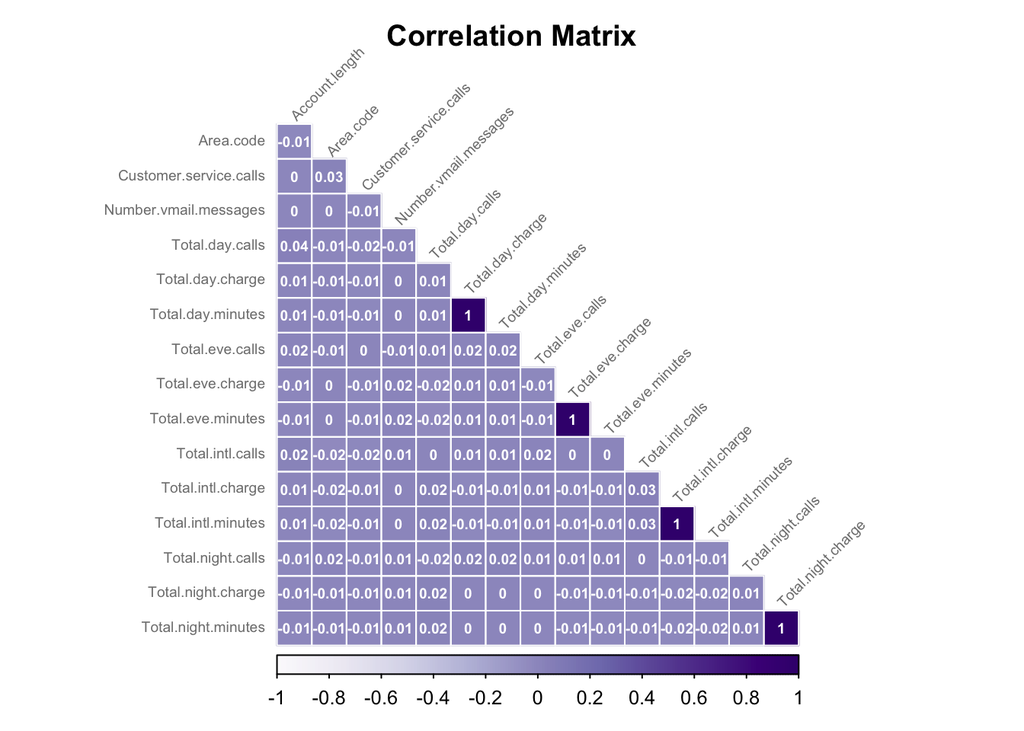

### Lower-dimensional models

Before proceeding with the full model we need to focus on some lower dimensional model in order to investigate some interesting relationships between the variables. We only include customers who have made a service call:

```r
service_calls <- data %>%
  filter(Customer.service.calls > 0)
```

This is the proportion of customers who churned after making a service call:

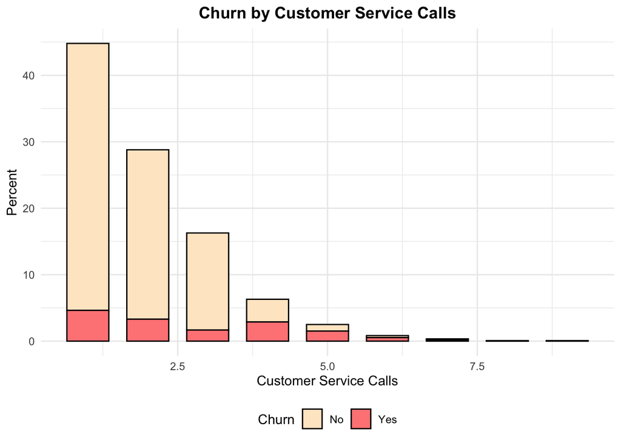

We can see that the churn rate increases as the number of customer service calls increases. This suggests that customers who make more service calls are more likely to churn.

### Preprocessing and feature engineering

We’ll use the regions column for the first models to avoid having high-cardinality encoded columns: we store the variable in order to use it later with more robust models (tree-based).

```r
state.column <- data$State
data$State <- NULL
```

Now let’s re-do the chi square:

```r
contingency.table <- table(data$Region, data$Churn)
chisq.test(contingency.table)
```

```
##
##  Pearson's Chi-squared test
##
## data:  contingency.table
## X-squared = 5.9403, df = 4, p-value = 0.2036
```

H0: Region and Churn are independent, H1: Region and Churn are dependent. Since p-value > 0.05, we fail to reject the null hypothesis, therefore the region does not influence the churn rate. Let’s see the distribution of churn by region:

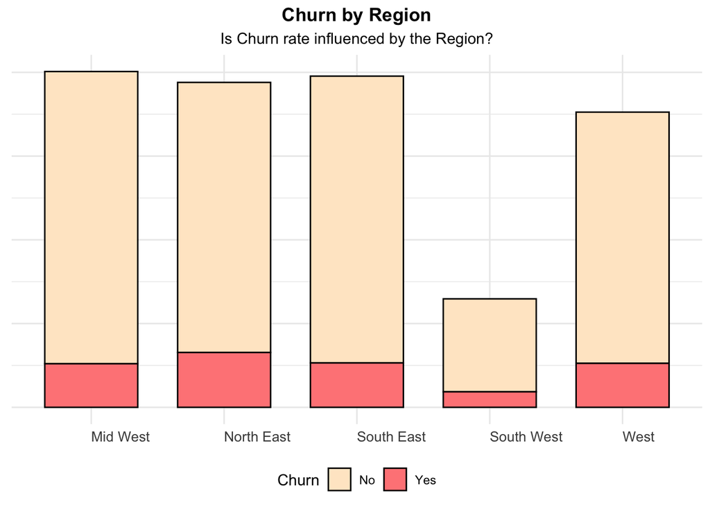

We can see that the churn rate is not influenced by the region.

#### Splitting the data and scaling

```r
set.seed(1)
ids.train <- sample(1:nrow(data), size = 0.75 * nrow(data), replace = FALSE)
data.train <- data[ids.train,]
data.val <- data[-ids.train,]
```

We oversample the minority class to balance the dataset, now we have 4260 total observations.

```r
data.train.balanced <- ovun.sample(Churn ~ ., data = data.train, method = "over", N=4260)$data
table(data.train.balanced$Churn)
```

```
##
## False  True
##  2130  2130
```

In order to to prevent certain columns from dominating the model, we scale it using the training data’s mean and standard deviation:

```r
cols_to_scale <- c("Account.length", "Area.code", "Number.vmail.messages", "Total.day.calls", "Total.day.charge", "Total.eve.calls", "Total.eve.charge", "Total.night.calls", "Total.night.charge", "Total.intl.calls", "Total.intl.charge", "Customer.service.calls")

train.mean <- apply(data.train.balanced[, cols_to_scale], MARGIN = 2, FUN = mean)
train.sd <- apply(data.train.balanced[, cols_to_scale], MARGIN = 2, FUN = sd)

data.train.balanced[, cols_to_scale] <- scale(data.train.balanced[, cols_to_scale], center = train.mean, scale = train.sd)
data.val[, cols_to_scale] <- scale(data.val[, cols_to_scale], center = train.mean, scale = train.sd)
```

#### Baseline Logistic Regression Model

Our starting point is a logistic regression model. We will use this model as a baseline to compare the performance of more complex models:

```r
logistic.baseline <- glm(Churn ~ ., data = data.train.balanced, family = "binomial")
```

The baseline model shows decent accuracy at 83.33%, however, precision at 57.89% and recall at 42.04% indicate areas for potential improvement. This is normal since we still have to perform feature selection and regularization to improve the model.

```
##
## baseline.pred False True
##             0   629   48
##             1    91   66
```

```
##    Accuracy Precision    Recall        F1
## 1 0.8333333 0.5789474 0.4203822 0.4870849
```

##### AIC and BIC Model Selection

We performed the **Akaike Information Criterion** (AIC) stepwise selection to identify the most important predictors in the model:

```r
akaike.fw <- step(glm(Churn ~ 1, family = "binomial", data = data.train.balanced), scope = formula(logistic.baseline), direction = "forward")
akaike.back <- step(logistic.baseline, direction = "backward")
akaike.both <- step(logistic.baseline, direction = "both")
```

Across all selection methods, certain predictors consistently appear as significant: “International.plan”, “Customer.service.calls”, “Total.day.charge” and “Voice.mail.plan”.

**Bayesian Information criterion** (BIC) is another criterion to select the best model. We will use the BIC to compare the models selected by the AIC:

```r
bayesian.fw <- step(glm(Churn ~ 1, family = "binomial", data = data.train.balanced), scope = formula(logistic.baseline), direction = "forward", k = log(nrow(data.train.balanced)))
bayesian.back <- step(logistic.baseline, direction = "backward", k = log(nrow(data.train.balanced)))
bayesian.both <- step(logistic.baseline, direction = "both", k = log(nrow(data.train.balanced)))
```

Considering bidirectional elimination of both methods, BIC is more strict as it removes all the covariates representing the regions.

After that we compare the validation set results:

The results show that the model selected by the AIC method performs slightly better than the one selected by the BIC method. The AIC model has a higher accuracy, precision, recall, and F1 score: maybe dropping all the region features as BIC does is too big of a loss of informations.

**AIC**:

```
##
## akaike.preds False True
##            0   631   47
##            1    89   67
```

```
##    Accuracy Precision    Recall        F1
## 1 0.8369305 0.5877193 0.4294872 0.4962963
```

**BIC**:

```
##
## bayesian.preds False True
##              0   627   48
##              1    93   66
```

```
##    Accuracy Precision    Recall        F1
## 1 0.8309353 0.5789474 0.4150943 0.4835165
```

#### ROC Curves

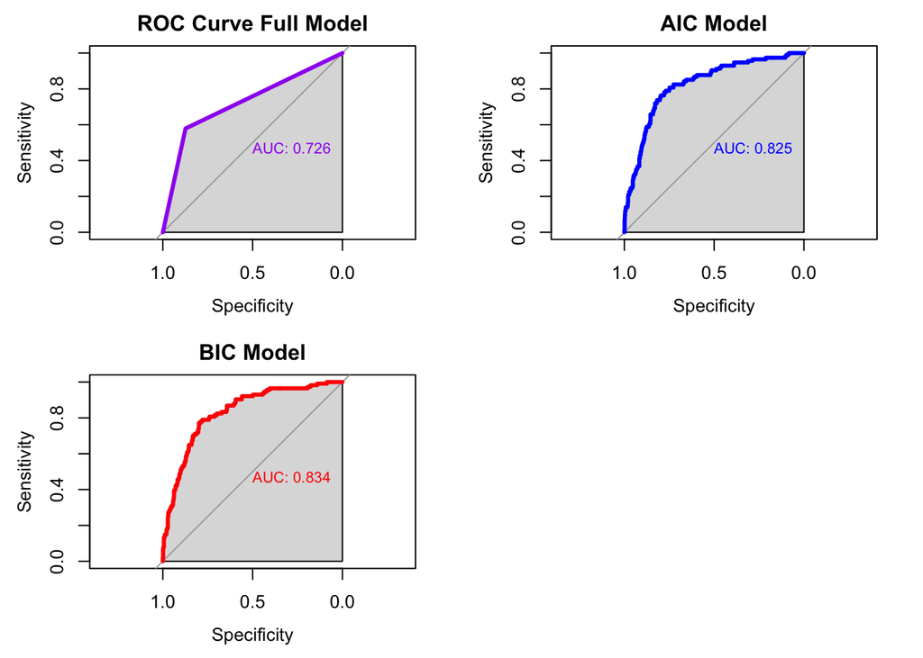

**AUC**: In order to insight into the models’ ability to evaluate their predictive performance in discerning churn, we’re calculating the Area Under the Curve (AUC) for Akaike, Bayesian, and Baseline models.

```r
auc_akaike <- as.numeric(auc(roc(data.val$Churn, predict(akaike.both, newdata = data.val, type = "response"))))
auc_bayesian <- as.numeric(auc(roc(data.val$Churn, predict(bayesian.both, newdata = data.val, type = "response"))))
auc_full <- as.numeric(auc(roc(data.val$Churn, baseline.pred)))
```

##### LASSO and RIDGE REGULARIZATION

We will use LASSO and Ridge regularization to improve the logistic regression model. We will use:

-`glmnet` package to perform the regularization;

- `cv.glmnet` function to perform cross-validation to find the optimal value of the regularization parameter lambda;
- `glmnet` function to fit the model with the optimal lambda value.

**LASSO**:

```r
set.seed(1)
ctrl <- trainControl(method = "cv", number = 10)
lasso <- train(Churn ~ ., data = data.train.balanced, method = "glmnet", metric = "Accuracy", trControl = ctrl, tuneGrid = expand.grid(alpha = 1, lambda = seq(0, 0.15, length = 30)))
max(lasso$results$Accuracy)
```

```
## [1] 0.7741784
```

```r
lasso$bestTune
```

```
##   alpha lambda
## 1     1      0
```

```r
lasso.predict <- predict(lasso, data.val)
lasso.cm <- table(lasso.predict, data.val$Churn)
lasso.metrics <- get.metrics(lasso.cm)
```

**RIDGE**:

```r
set.seed(1)
ridge <- train(Churn ~ ., data = data.train.balanced, method = "glmnet", metric = "Accuracy", trControl = ctrl, tuneGrid = expand.grid(alpha = 0, lambda = seq(0, 0.15, length = 30)))
max(ridge$results$Accuracy)
```

```
## [1] 0.7706573
```

```r
ridge$bestTune
```

```
##   alpha     lambda
## 3     0 0.01034483
```

```r
ridge.predict <- predict(ridge, data.val)
ridge.cm <- table(ridge.predict, data.val$Churn)
ridge.metrics <- get.metrics(ridge.cm)
```

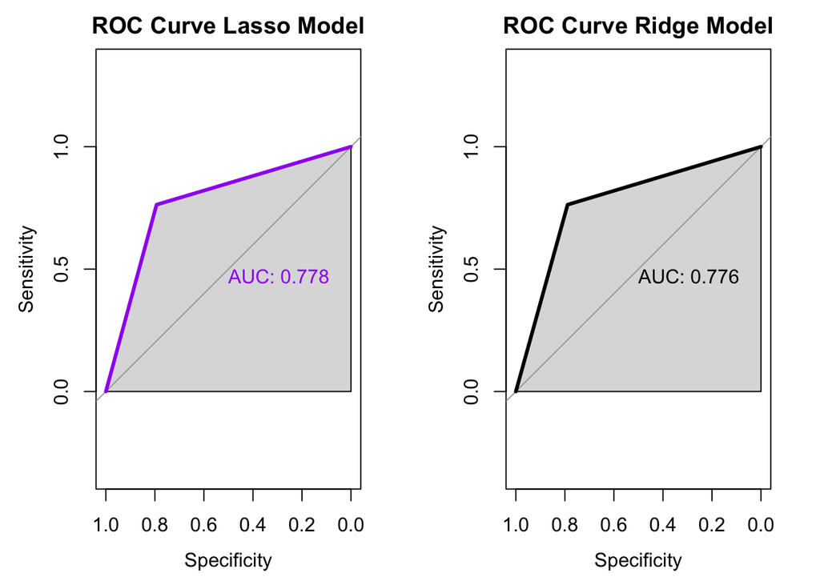

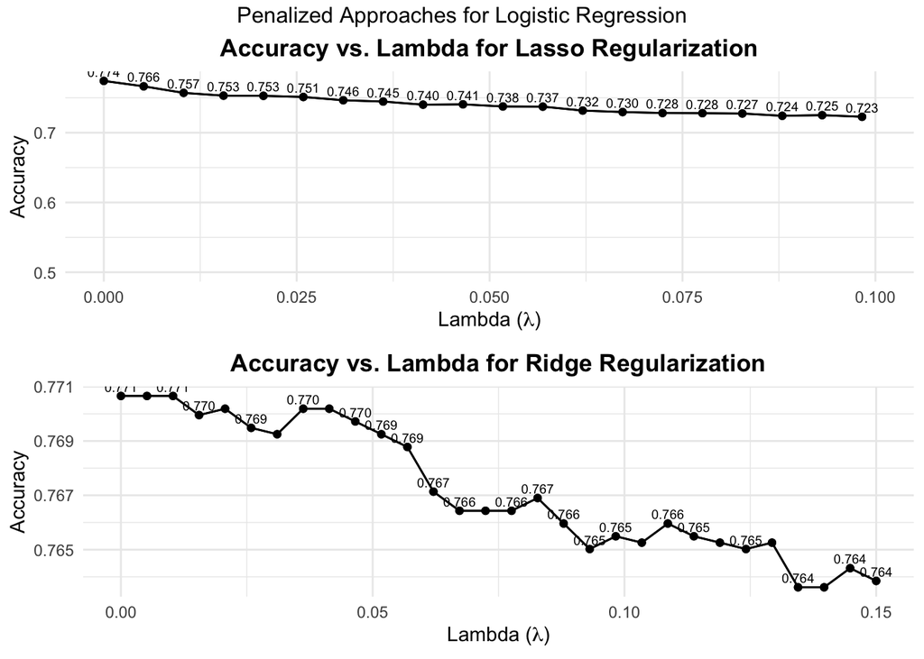

Now let’s compare the metrics obtained with the different models:

```
##            Model  Accuracy Precision    Recall  F1_Score       AUC
## 1         Akaike 0.8369305 0.5877193 0.4294872 0.4962963 0.8249269
## 2       Bayesian 0.8309353 0.5789474 0.4150943 0.4835165 0.8343567
## 3  Full Logistic 0.8333333 0.5789474 0.4203822 0.4870849 0.7262792
## 4 Logistic Ridge 0.7853717 0.7631579 0.3640167 0.4929178 0.7760234
## 5 Logistic Lasso 0.7889688 0.7631579 0.3686441 0.4971429 0.7781067
```

Overall, the model performs reasonably well but could benefit from increased recall to capture more positive cases.

#### Other models

From now on we are studying other models and comparing the metrics with the logistic regression we chose as baseline model:

- **Decision trees**
- **Random Forest**
- **Gradient Boosting**

#### Decision Trees

First of all we split again to undo the scaling and to make trees more interpretable for us:

```r
set.seed(1)
ids.train <- sample(1:nrow(data), size = 0.75 * nrow(data), replace = FALSE)
data.train <- data[ids.train,]
data.val <- data[-ids.train,]
```

Then we oversampled the minority class in order to have a total of 4260 observations as in the previous case:

[figure not shown]

[output not shown]

[output not shown]

```r
data.train.balanced <- ovun.sample(Churn ~ ., data = data.train, method = "over", N=4260)$data
table(data.train.balanced$Churn)
```

[output not shown]

##### Pruning the tree

In order to improve the performance and generalization ability of decision trees (to prevent overfitting) we adopted a Pruning approach with cross-validation:

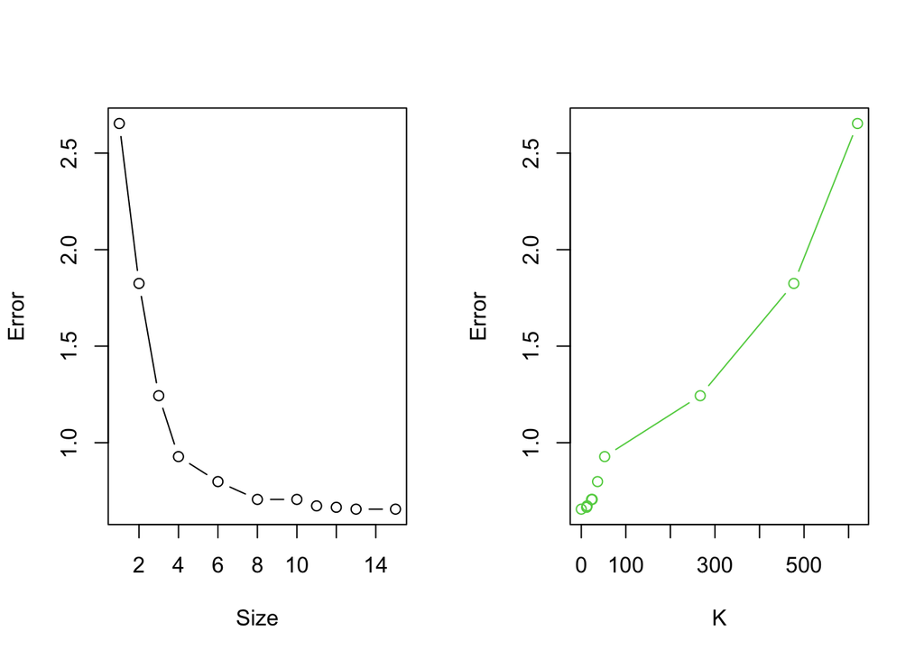

After pruning, the resuting tree is the following:

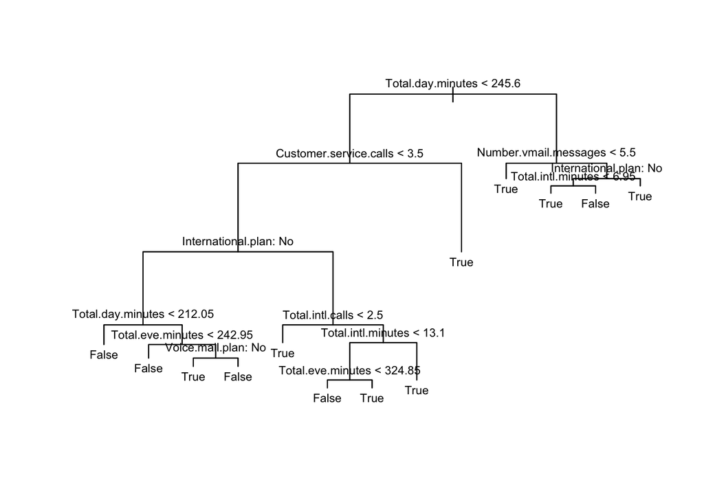

The predictive performance of the pruned tree is evaluated on the validation dataset, giving as contingency table the below:

```
##
## pruned.pred False True
##       False   651   14
##       True     69  100
```

#### Random Forest

Now its the turn of the Random Forest model. Using again a seed set for reproducibility, we train the model on a balanced training dataset, configuring parameters such as the number of trees and variable selection for each split (500).

```r
set.seed(1)
fit.bag <- randomForest(Churn ~ ., data = data.train.balanced, mtry = ncol(data.train.balanced) - 1, ntree = 500, importance = T)
```

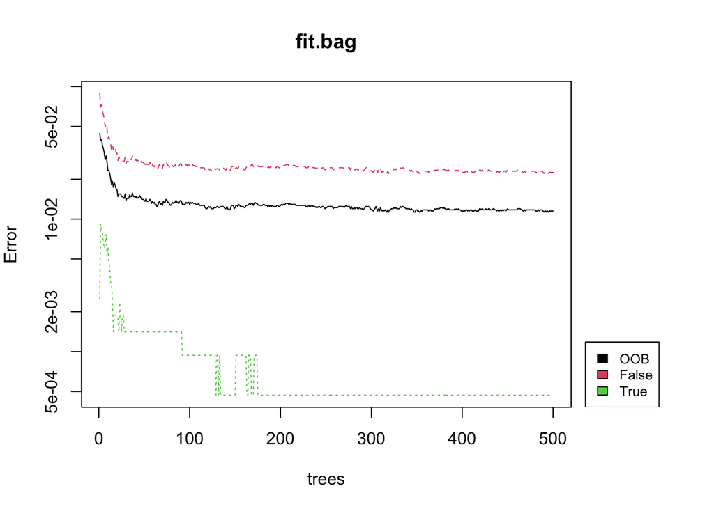

In this section, we evaluate our bagged model’s performance on the validation dataset:

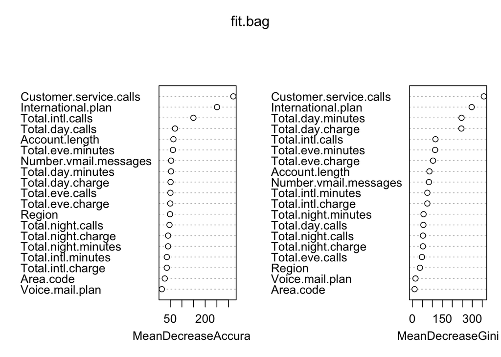

```
## [1] 0.01296275
```

```
## [1] 0.03357314
```

```
##
## validation.preds False True
##            False   713   21
##            True      7   93
```

#### eXtreme Gradient Boosting

We’re now using XGBoost to build a churn prediction model. First, we’ll prepare our data by encoding categorical variables and splitting it into training and validation sets, then, we’ll train the XGBoost model with specified parameters.

```r
X.tr <- model.matrix(Churn ~ ., data = data.train.balanced)[, -1]
y.tr <- as.numeric(data.train.balanced$Churn)-1
X.val <- model.matrix(Churn ~ ., data = data.val)[, -1]
y.val <- as.numeric(data.val$Churn)-1
fit.xg <- xgboost(as.matrix(X.tr), label = y.tr, nrounds = 50, objective = "binary:logistic", eval_metric = "error")
```

```
##
## xg.pred False True
##       0   713   18
##       1     7   96
```

```
##   Accuracy Precision    Recall        F1
## 1 0.970024 0.8421053 0.9320388 0.8847926
```

[output not shown]

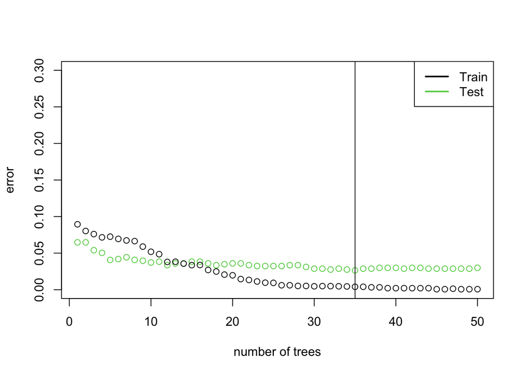

##### Feature Importance

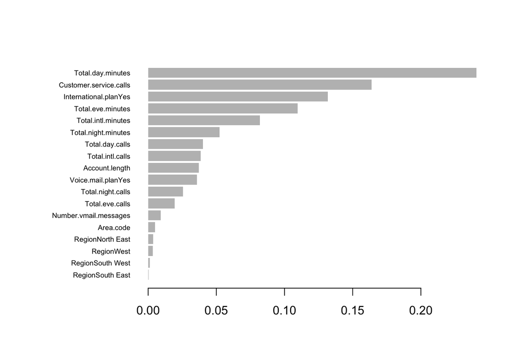

Notably, **total day minutes, customer service calls, and the presence of an international plan emerge as the top features**, indicating their significant influence on customer churn. Other factors such as evening and international call durations also contribute to the model’s predictive power, albeit to a lesser extent.

[output not shown]

[output cut: 395 more lines]

[output not shown]

Here we can see from the confusion matrix that the model has a good performance, but if compared to the matrix shown at the beginning of the section, we can see that the model improved in the prediction of true positives (96 before, 98 now), but has a slightly worse performance in predicting true negatives (713 before, 707 now).

```
##
## pred_xg_cv False True
##      False   707   16
##      True     13   98
```

### Main conclusions

#### Main conclusions

To sum up, we have performed a comprehensive analysis of the churn dataset, including data exploration, preprocessing, and feature engineering. We have built a logistic regression model as a baseline and compared its performance with other models, such as decision trees, random forests, and gradient boosting.

```
##               Model  Accuracy Precision    Recall  F1_Score       AUC
## 1            Akaike 0.8369305 0.5877193 0.4294872 0.4962963 0.8249269
## 2          Bayesian 0.8309353 0.5789474 0.4150943 0.4835165 0.8343567
## 3     Full Logistic 0.8333333 0.5789474 0.4203822 0.4870849 0.7262792
## 4    Logistic Ridge 0.7853717 0.7631579 0.3640167 0.4929178 0.7760234
## 5    Logistic Lasso 0.7889688 0.7631579 0.3686441 0.4971429 0.7781067
## 6 CV Decision Trees 0.9004796 0.8771930 0.5917160 0.7067138 0.8906798
## 7    Random Forests 0.9664269 0.8157895 0.9300000 0.8691589 0.9030336
## 8            CV XGB 0.9652278 0.8596491 0.8828829 0.8711111 0.9207968
```

## Task 2

Cluster customers according to their behavior